# PA-PML

CH Khalid

Monday, April 20, 2015

## Goal of studie

Aim of this project is to predict the manner in which the six young health participants did the exercise.represented in the training set with the “classe” variable :

- **Class A** : exactly according to the specification,
- **Class B** : throwing the elbows to the front,
- **Class C** : lifting the dumbbell only halfway,
- **Class D** : lowering the dumbbell only halfway,
- **Class E** : throwing the hips to the front.

### Load the required packages

```r
library(caret)
library(rpart)
# set a random seed for reproducing results.
set.seed(8888)
```

## Load the dataset

first load the data in to **Rconsole** :

```r
pml_training <- read.csv("pml-training.csv",head=TRUE,sep=",")
dim(pml_training)
```

```
## [1] 19622   160
```

## Data preprocessing (Reducing the number of attributes)

### Training Dataset:

```r
missing_data<-sapply(pml_training,function(x) any(is.na(x)| x==""))
releventVar<-grepl("belt|arm|dumbbell|forearm|classe", names(missing_data))
predVar<-c(!missing_data & releventVar)
pml_train<-pml_training[,predVar]
dim(pml_train)
```

```
## [1] 19622    53
```

### Testing Dataset:

```r
pml_testing <- read.csv("pml-testing.csv",head=TRUE,sep=",")
missing_data_test<-sapply(pml_testing,function(x) any(is.na(x)| x==""))
releventVar_test<-grepl("belt|arm|dumbbell|forearm|problem_id", names(missing_data_test))
predVar_test<-c(!missing_data_test & releventVar_test)
pml_test<-pml_testing[,predVar_test]
dim(pml_test)
```

```
## [1] 20 53
```

```r
#verify identical variables for train and test?
identical(names(pml_train[,-53]),names(pml_test[,-53]))
```

```
## [1] TRUE
```

## Data Cross Validation

Partioning the data set into two random sample, 75% for “training” and 25% for “testing”. And fit the model using training data and then predit using testing data.

```r
inTrain <- createDataPartition(y=pml_train$classe,p=0.75, list=FALSE)
training <- pml_train[inTrain,]
testing <- pml_train[-inTrain,]
dim(training);dim(testing)
```

```
## [1] 14718    53
```

```
## [1] 4904   53
```

### algorithms for prediction : Decision Tree

we have choice the decision tree algorithme with complixity equal a 0 and 10 cross-validations.

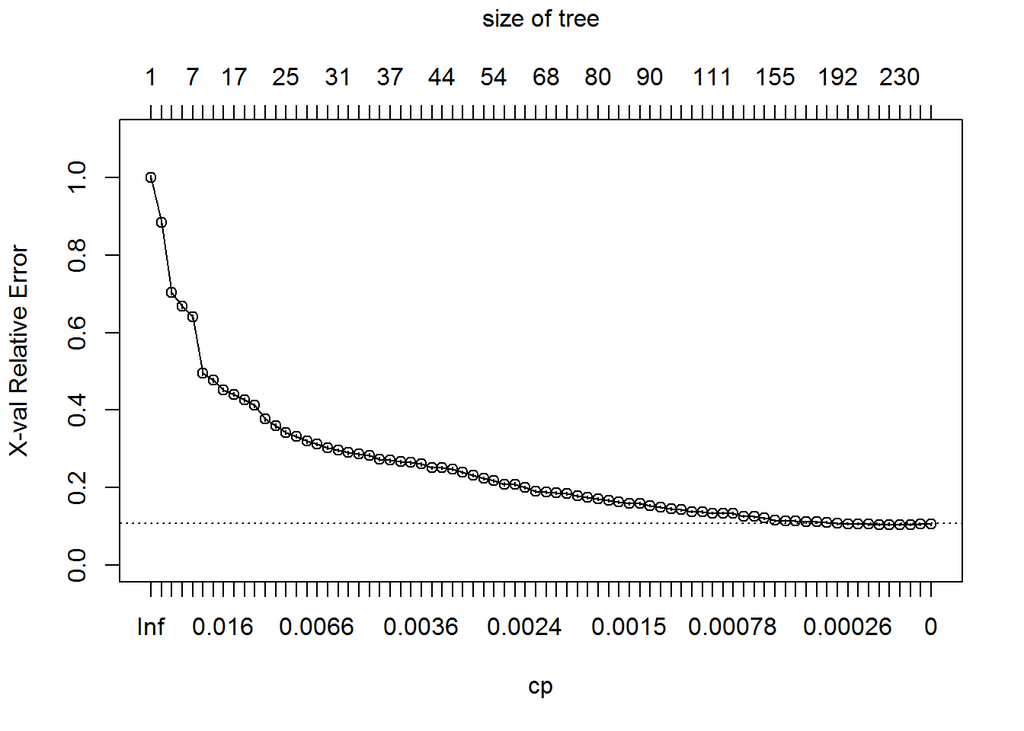

```r
model <- rpart(classe ~ .,control=rpart.control(xval=10, cp=0), data=training)
plotcp(model)
```

## Model performance

```r
prediction <- predict(model,type="class", newdata = testing)
tab1<-table(prediction,testing$classe)
tab1
```

```
##
## prediction    A    B    C    D    E
##          A 1335   26    8    6    7
##          B   28  880   25   14   19
##          C   13   18  797   23    5
##          D   15   14   19  742   19
##          E    4   11    6   19  851
```

```r
1-sum(diag(tab1))/sum(tab1)
```

```
## [1] 0.06097064
```

## Prediction result on the test data

Finally, using the model to predict how the six young health participants did the exercise in the 20 observation test data:

```r
prediction_id <- predict(model,newdata=pml_test,type="class")
prediction_id
```

```
##  1  2  3  4  5  6  7  8  9 10 11 12 13 14 15 16 17 18 19 20
##  B  A  B  A  A  E  D  B  A  A  B  C  B  A  E  E  A  B  B  B
## Levels: A B C D E
```